# Data 2401 Final Project

Marvin Bernardino

2023-11-06

# Texas Wide Open

Data 2401 Final Project

## Introduction

In 2013, Gov. Rick Perry launched the “Texas Wide Open For Business” campaign. Advertising campaigns were launched in major cities across California to lure them into moving to Texas (Texas Monthly, 2013).

In 2023, some Texans and other national figures are now blaming both California and these new migrants for whatever local problems these migrations may have caused.

Using some publicly available data, we will now try to answer whether these concerns are overblown or not.

## Data

The IRS publishes a yearly U. S. Population Migration Data (IRS, 2023). Every year, as taxes are filed, the IRS takes notes on address changes that tax filers report on their own income tax returns.

The data normally includes:

- number of returns filed (approximates the number of households)
- number of personal exemptions claimed (approximates the number of individiduals)
- total adjusted gross income

The data is usually prepared per year, which means it will take a lot of work to combine these data into bigger data sets, if year-to-year changes are to be analyzed.

Conveniently, user Patrick O’Connor in Kaggle, published a data set containing data from 1992 to 2020.

## Kaggle Data by Patrick O’Connor

Note that the IRS only begun including AGI data in 1993. Hence, there will be no AGI figures to be reported before that year (IRS, 2023). It is important to note that the AGI figure in 1993 is the figure earned by the migrant in 1992.

Thus, this report will capture the tax filer’s residence and income earned during the year they are trying to migrate, as opposed to the year they have successfully completed their move (signaled by the change in address in the next year’s tax return).

- **Y1** (the year when the individual filed their last tax return)
- **Y1_STATE_NAME** (name of the state where the individual filed their last return)
- **Y2** (the year when the individual filed their current tax return)
- **Y2_STATE_NAME** (name of the state the filer currently reside in)
- **NUM_RETURNS** (number of tax returns, approximates household)
- **NUM_EXEMPTIONS** (number of exemptions claimed, approximates number of individuals)
- **AGI** (adjusted gross income, the AGI represents the total income of all individuals who moved that particular year)

## Problems / Objectives

The dataset shows migration patterns year to year, by tracking Y1 and Y2 changes. As a bonus, it also includes the approximated number of households, the approximated number of individuals migrating to any state, and their approximated household income.

These are some of the questions this report might be ready to answer:

- What is the nature of Texas-California migration that can be gleamed from the data?
  - How many individuals are migrating to Texas from California?
  - Is Texas the number one destination for California migrants?
  - What is the net migration between Texas and California?
  - Do Californians make up the majority of those moving to Texas?
  - Are the residents of either state more likely to move to than the other?
- From which states are the majority of those moving to Texas?
- Using the AGI data, what other information can be gleamed from the migration data?
  - What is the household income of these migrants?
  - Does the migrant population differ from the population that stayed?
  - Does the migrant population differ from the residents of the state they are moving to?
- Was Gov. Rick Perry’s advertising campaign effective?
- What other information can be gleamed from these data?

## Limitations of the Data

The dataset in no way represents the actual number of migrants of any state. A good example of those who are left out are undocumented immigrants who do not file tax returns. Some undocumented immigrants use an Individual Taxpayer Identification number (ITIN), but the Statistics of Income Division of the IRS does not say anything in particular about this distinction. The Foreign component of the dataset actually refers to the District of Columbia, the Virgin Islands, Puerto Rico, AFO/FPO (military bases) and other areas (IRS, 2023).

## Packages Used

```r
library(tidyverse)
library(ggplot2)
```

## Raw Data

```
## Rows: 78,387
## Columns: 11
## $ Y1             <int> 1992, 1992, 1992, 1992, 1992, 1992, 1992, 1992, 1992, 1…
## $ Y1_STATE_FIPS  <int> 2, 2, 2, 2, 2, 2, 2, 2, 2, 2, 2, 2, 2, 2, 2, 2, 2, 2, 2…
## $ Y1_STATE_ABBR  <chr> "AK", "AK", "AK", "AK", "AK", "AK", "AK", "AK", "AK", "…
## $ Y1_STATE_NAME  <chr> "ALASKA", "ALASKA", "ALASKA", "ALASKA", "ALASKA", "ALAS…
## $ Y2             <int> 1993, 1993, 1993, 1993, 1993, 1993, 1993, 1993, 1993, 1…
## $ Y2_STATE_FIPS  <int> 2, 1, 5, 4, 6, 8, 9, 11, 10, 12, 57, 13, 15, 19, 16, 17…
## $ Y2_STATE_ABBR  <chr> "AK", "AL", "AR", "AZ", "CA", "CO", "CT", "DC", "DE", "…
## $ Y2_STATE_NAME  <chr> "ALASKA", "ALABAMA", "ARKANSAS", "ARIZONA", "CALIFORNIA…
## $ NUM_RETURNS    <int> 183618, 236, 160, 575, 1525, 644, 37, 26, 25, 628, 439,…
## $ NUM_EXEMPTIONS <int> 424179, 642, 342, 1135, 3209, 1403, 51, 52, 80, 1316, 8…
## $ AGI            <dbl> 7472048, 7453, 4639, 14744, 43777, 20125, 836, 910, 692…
```

The O’Connor Kaggle Data is still arranged year to year, with each state, starting at **Y1_STATE…**, with an accompanying **Y2_STATE….** Note that **Y1_STATE** and **Y2_STATE** can be equal, which means that these are the tax filers who did not move to another state.

**FIPS** codes stand for Federal Information Processing System Codes for States and Counties. The number uniquely identify geographic areas, for example, the state-level FIPS code for Texas is 48 (Federal Communications Commission). The O’Connor Dataset retained the state-level FIPS code but excluded the county-level FIPS codes. Hence, this report is currently limited to only analyzing state-level migration.

The **AGI** stands for aggregate gross income and is reported in the thousands. This means that to obtain the true AGI in dollars, they must be multiplied by 1000.

Each line in the data includes Y1 (migration year), Y2 (filing year), Y1_State_x (previous state), Y2_State_x (current state), NUM_RETURNS (number of tax returns filed in Y1), AGI (the total income of all the filers in NUM_RETURNS).

## California to Texas Migration Data, 1993 to 2020

To obtain migration data from California to Texas, we use Y1_STATE_ABBR = “CA” and Y2_STATE_ABBR == “TX” to filter the data.

```
##    Year Californians     AGI NUM_RETURNS
## 1  1992        58639  808610       25539
## 2  1993        61418  884066       26585
## 3  1994        55266  838274       24328
## 4  1995        48758  814723       21777
## 5  1996        42997  770213       19628
## 6  1997        42070  862369       19678
## 7  1998        41864  905246       19741
## 8  1999        42901  999452       20109
## 9  2000        41723 1124429       19981
## 10 2001        44091 1027272       21163
## 11 2002        41048  975982       19570
## 12 2003        43207  982034       20009
## 13 2004        54039 1237008       24181
## 14 2005        72401 1592795       30591
## 15 2006        82537 1769931       34078
## 16 2007        67309 1586155       30286
## 17 2008        56682 1316386       26737
## 18 2009        48877 1162082       23626
## 19 2010        48419 1291251       23621
## 20 2011        55278 1693828       27381
## 21 2012        64053 2369471       30771
## 22 2013        71321 2187995       33626
## 23 2014        50924 1804603       25288
## 24 2015        62767 2353043       30052
## 25 2016        88964 3549333       41707
## 26 2017        70130 3143998       34526
## 27 2018        72306 3448399       36103
## 28 2019        87707 4569503       42892
## 29 2020       105434 7221838       52816
```

# Graph of California Migration to Texas

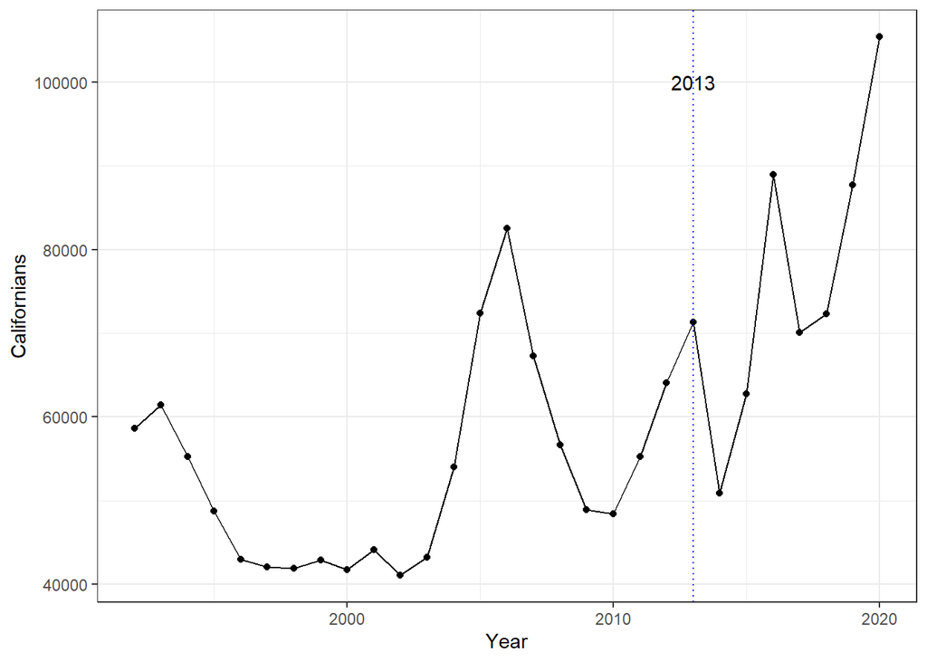

## Texas vs. California Migration Data, 1992 to 2020

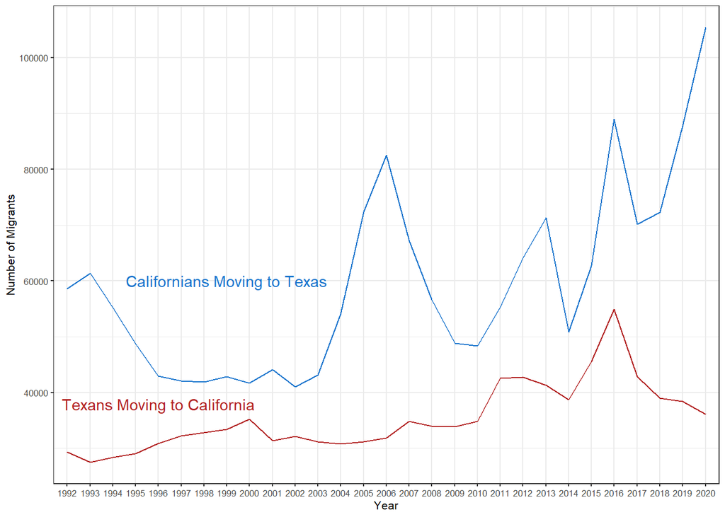

Note that net migration between California and Texas favors California migration to Texas.

## Top 3 Destinations for California Migrants, 1992 to 2020.

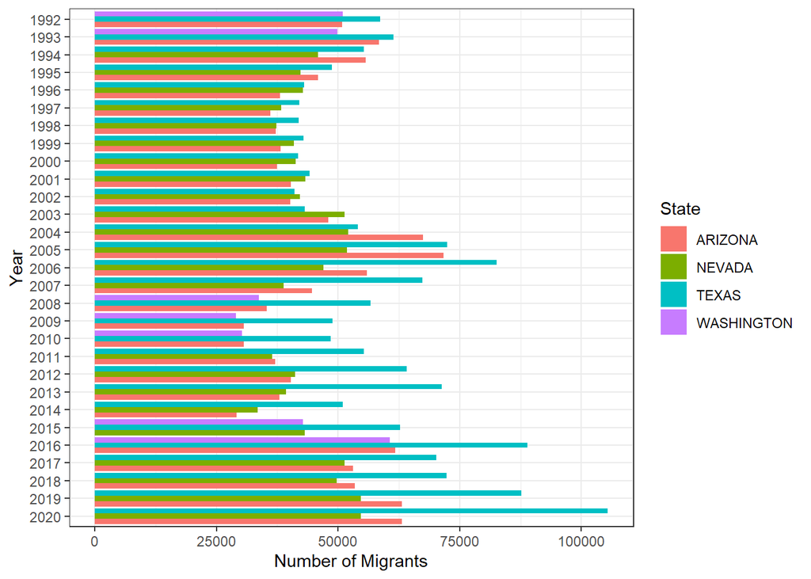

Note that Californians began moving to Texas in greater numbers starting in 2004.

## Top Destinations of Texas Migrants

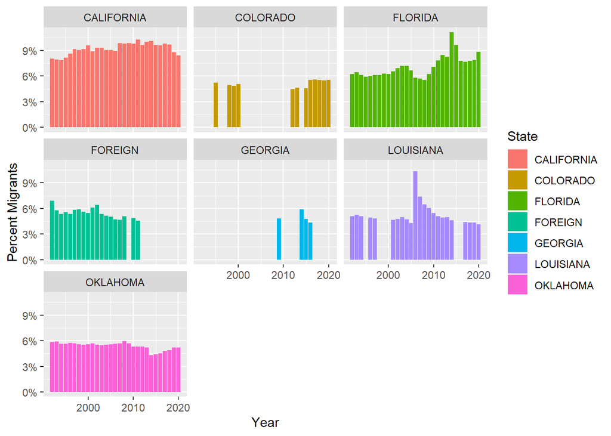

Note that a significant population of Texans leave for a “foreign” country, from 1990s to 2010. Also note that, in 2006, there is a spike in Texans moving to Louisiana.

## Non-migrant Population of Texans

```
## # A tibble: 29 × 2
## # Groups:   Year [29]
##    Year  Percent_Migration
##    <fct>             <dbl>
##  1 1992               97.4
##  2 1993               97.6
##  3 1994               97.5
##  4 1995               97.6
##  5 1996               97.6
##  6 1997               97.7
##  7 1998               97.7
##  8 1999               97.7
##  9 2000               97.7
## 10 2001               97.9
## # ℹ 19 more rows
```

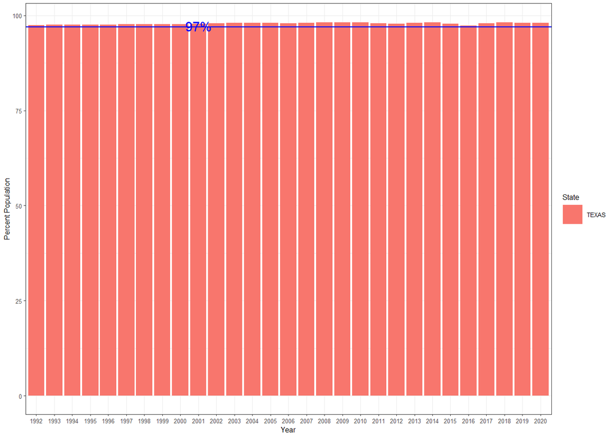

Between 2-3% of Texans migrate annually for other states.

## Top Destinations for California Migrants

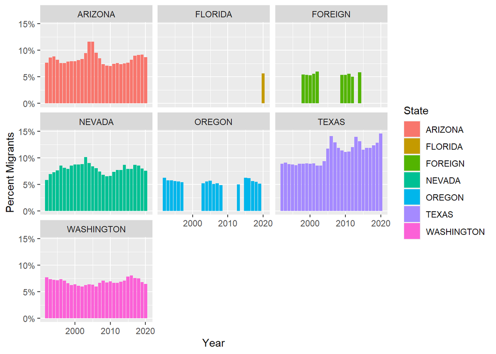

## Non-migrant Population of California

```
## # A tibble: 29 × 2
## # Groups:   Year [29]
##    Year  Percent_Migration
##    <fct>             <dbl>
##  1 1992               97.2
##  2 1993               97.1
##  3 1994               97.3
##  4 1995               97.6
##  5 1996               97.8
##  6 1997               98.0
##  7 1998               98.1
##  8 1999               98.1
##  9 2000               98.2
## 10 2001               98.1
## # ℹ 19 more rows
```

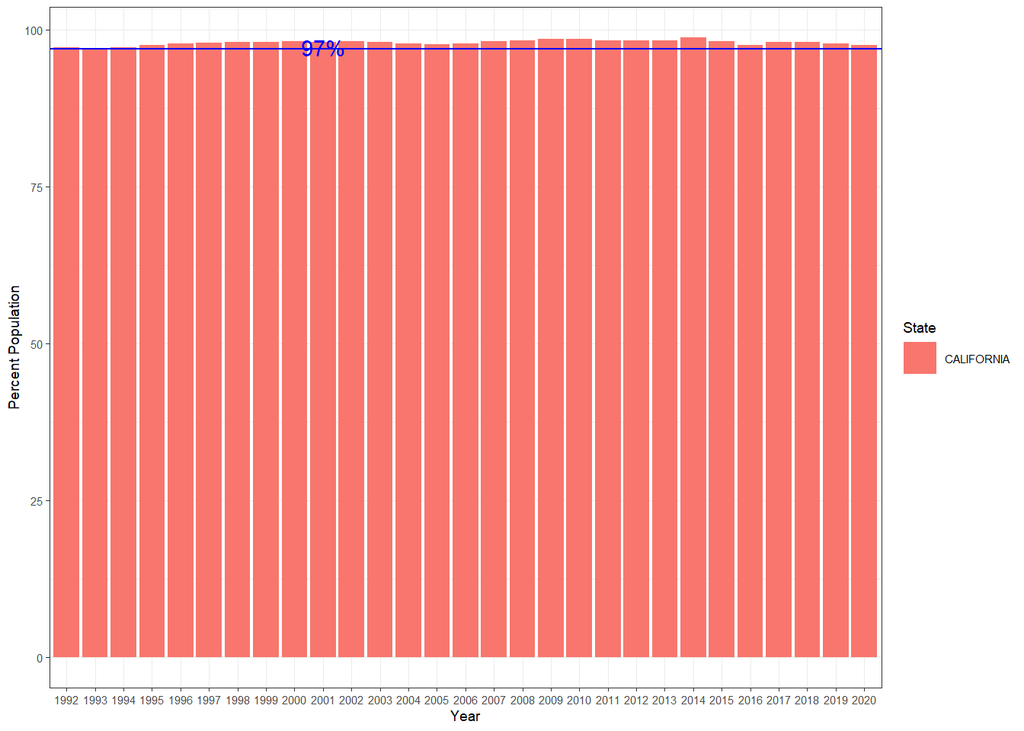

Both California and Texas have similar levels of migration – 97-98% do not migrate.

## Top State Migrants Moving to Texas

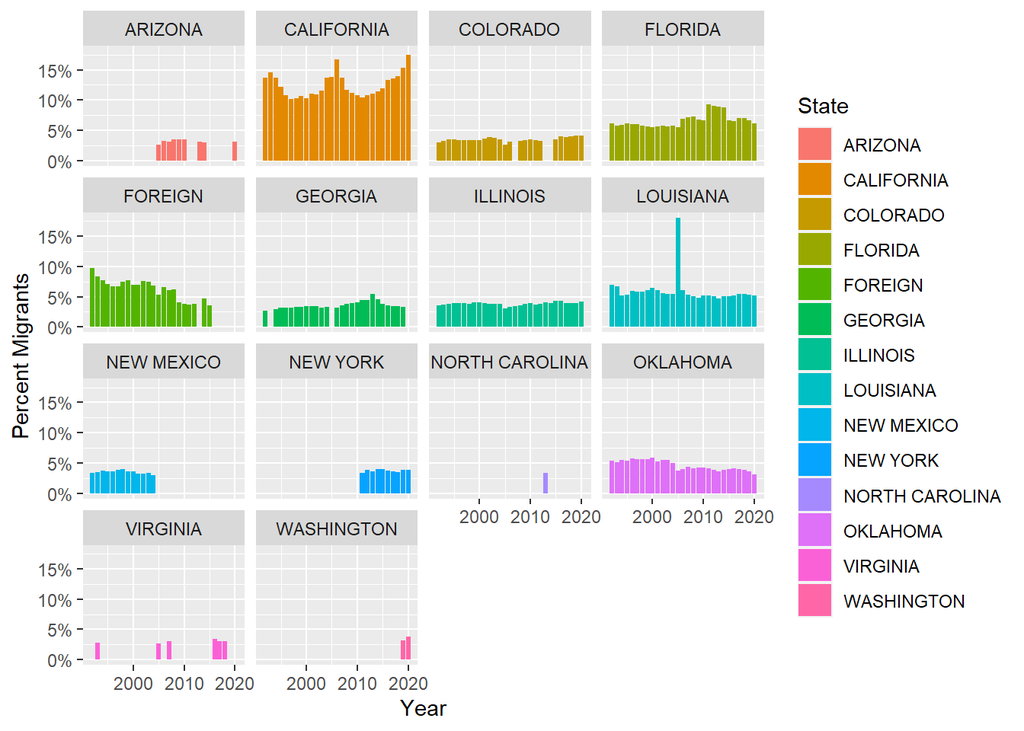

Californians feature prominently in this data. However, notice the jump in Louisiana in the mid-2000’s,

## Louisiana Migrants moving to Texas, A Closer Look

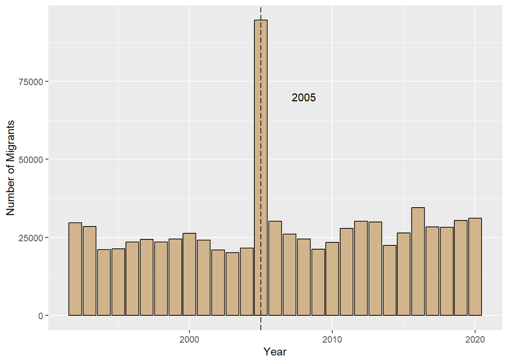

## Household Income of Californians Migrating to Texas

Both the IRS and O’Connor’s Kaggle Data provide AGI, the aggregate gross income of all transplants expressed in thousands of dollars. If AGI is divided by the number of tax returns filed, we can now obtain the average household income for that particular year.

Average Household Income = (AGI * 1000 ) / NUM_RETURNS

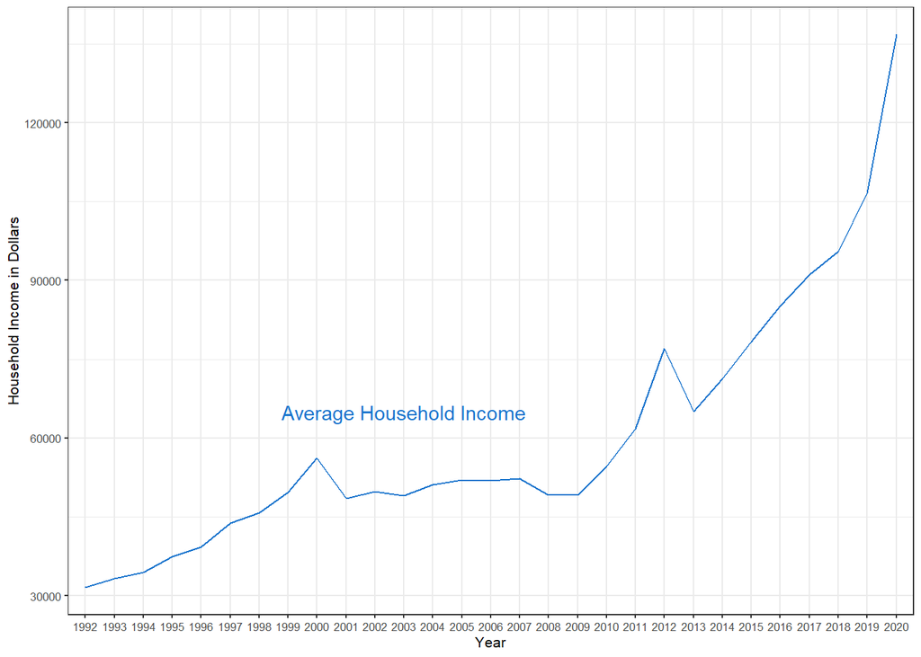

After 2009, the average household income of California migrants start to increase.This is the reported data in that particular year and may not reflect inflation. Therefore, the data must be corrected for inflation.

## Applying Inflation Correction (in 2022 dollars) Part 1

To perform an inflation correction, the average CPI data every year from 1992 to 2020 was obtained from the Federal Reserve Data (FRED, 2023).

To perform an example calculation, the inflation rate in 2020 compared to 2022 dollars by:

2020 Inflation Rate = [(CPI_2022 - CPI_2020 )/ (CPI_2020)] * 100%

2020 Income in 2022 dollars = [2020 Income * (1 + Inflation Rate) ]

This can now be applied to the whole dataset.

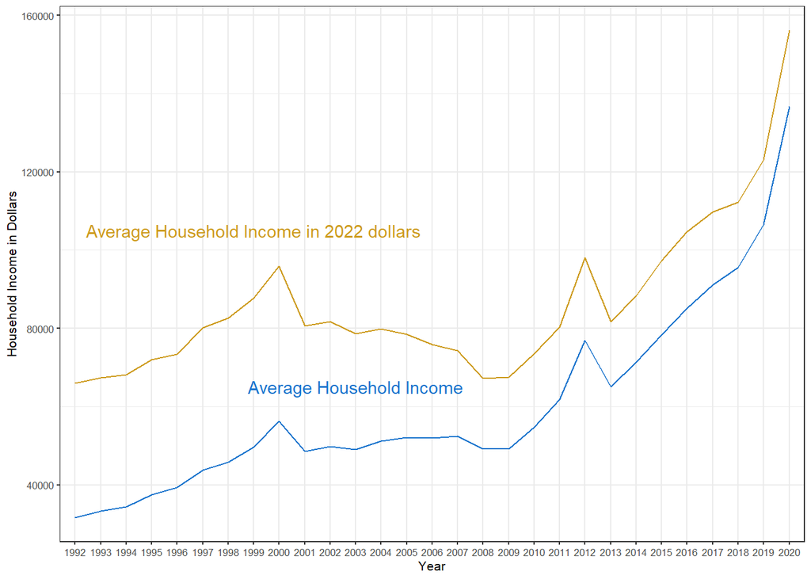

Applying inflation correction, the average household income for California migrants to Texas has been somewhat steady, averaging 80,000 dollars until 2009 – when it starts to increase at a rapid rate.

## Comparing California Median Household Income versus Texas-bound Californians

To further explore the data, the average household income of the California migrant can be compared with the median household income of California. The St. Louis Fed provides the Median Household Income in California in “Current Dollars, Not Seasonally Adjusted,” (FRED, 2023). Taking into consideration that the data is in “current dollars” (2022), it is believed that the data has already been corrected for inflation.

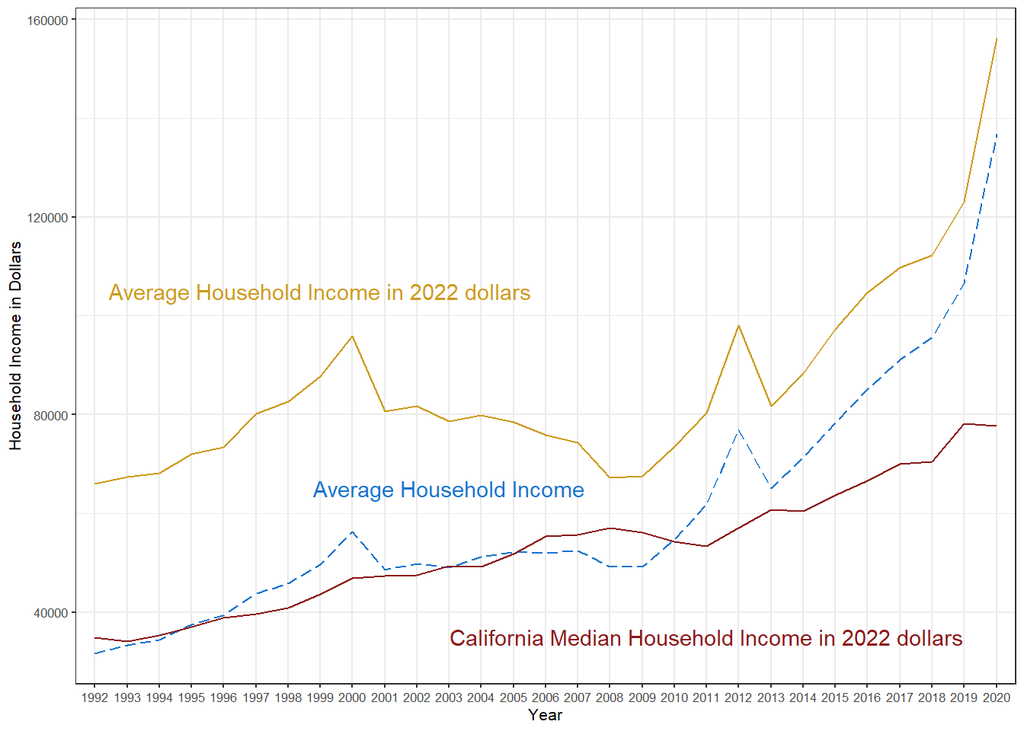

It can be expected that migrants as a whole – should be better off than the average family. Moving itself, is an expensive venture, and can only be undertaken by those who can afford it. There is reason to believe that the California Median Household Income provided by the St. Louis Fed, has already been corrected for inflation.

During the latter part of 2010’s, the average household income of the California migrants starts to increase rapidly, reaching nearly 160,000 dollars by 2020.

Note that the average household income of these California migrants dropped in the year 2001 which might signal that they have been significantly affected by the bursting of the Dot-com bubble. Also, note that the median California household’s income was not affected as much by the Dot-com crisis.

## Texas Median Household Income versus the California migrants

Using the same data from the St. Louis Fed, the average household income of the California migrant to Texas can be compared to the median household income of Texans.

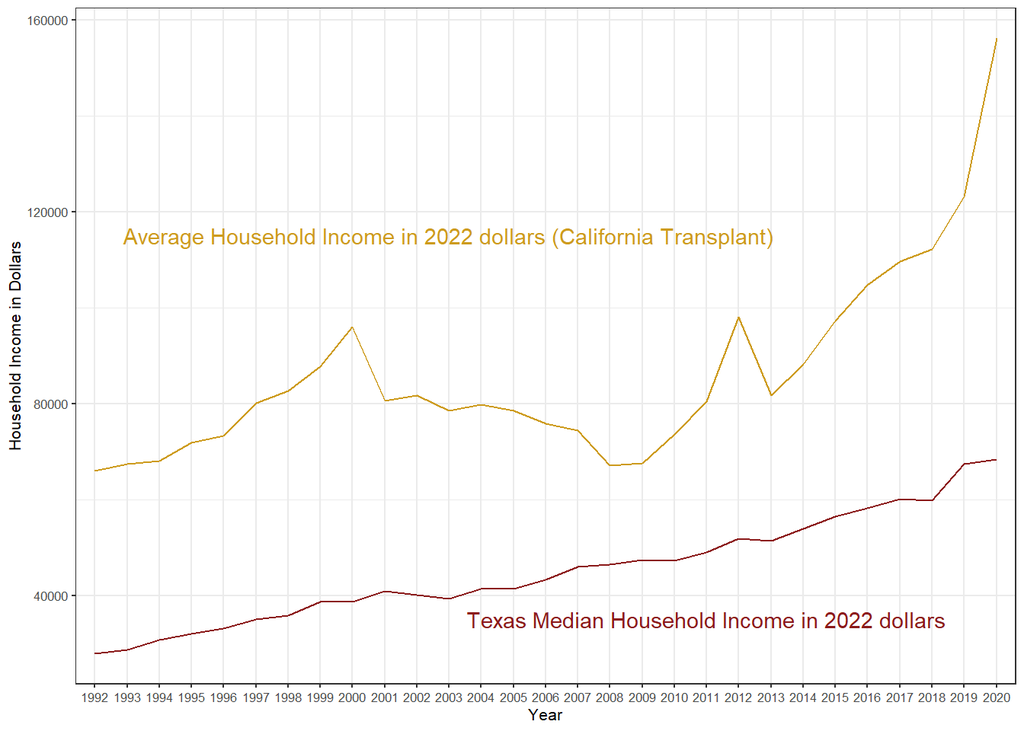

The gap between the Texas median household income and the average household income of the California migrant is roughly double. In 2020, there is a almost a 100,000 income gap between the two groups.

## Summary

Between 2-3% of residents of both California and Texas move somewhere else. If investigated further, the SOI data will reveal if this average is true for all states but that it is not within the scope of this report.

The data also shows that the average California transplant is incredibly well-off, earning double the median household income in California and Texas. In 2020, the average California migrant’s household income has risen above 150,000 dollars.

In all, the influx of high-income California migrants to Texas presents different kinds of problem. They may drive up housing prices and may affect the availability of housing for local Texas residents. They may also increase investments and commerce in the state. To the dismay of the state politicians, these residents may also shape elections. Harris County was once a Republican stronghold, but now leans reliably Democratic (Hobby School of Public Affairs, 2023). In the SOI data, we see migration to Texas picking up in 2004. By the presidential election year of 2008, Harris County has voted for the Democratic candidate since then. These factors, however, are outside the scope of this report.

## References

Bureau of Labor Statistics. (2023, November). *Average CPI by Quarter and Year*. Social Security Administration. https://www.ssa.gov/oact/STATS/avgcpi.html

Federal Communications Commission. (2023). *States and Counties FIPS codes*. https://transition.fcc.gov/oet/info/maps/census/fips/fips.txt

Federal Reserve Economic Data, St. Louis FED. (2023, November). *Median Household Income in California*. Economic Research, Federal Reserve Bank of St. Louis. https://fred.stlouisfed.org/series/MEHOINUSCAA646N

Federal Reserve Economic Data, St. Louis FED. (2023, November). *Median Household Income in Texas*. Economic Research, Federal Reserve Bank of St. Louis. https://fred.stlouisfed.org/series/MEHOINUSTXA646N

Herzog, M., Texas Monthly Staff. (2013, February 5). *Rick Perry to Californians: Come Check Out Texas.* Texas Monthly. https://www.texasmonthly.com/news-politics/rick-perry-to-californians-come-check-out-texas/

Hobby School of Public Affairs. (2023). *Harris County’s Changing Electoral Landscape*. University of Houston. https://uh.edu/hobby/harriscounty/

Internal Revenue Service. (2023, April 27). *SOI Tax Stats - Migration Data.* Tax Statistics. https://www.irs.gov/statistics/soi-tax-stats-migration-data

National Weather Service. (2022, September). *Hurricane Katrina - August 2005.* National Oceanic and Atmospheric Administration. https://www.weather.gov/mob/katrina

O’Connor, P. (2023, September). *IRS Migration Data - 1992 to 2020.* kaggle. https://www.kaggle.com/datasets/wumanandpat/irs-migration-data-1992-to-2020

Office of the Texas Governor. (2023) *Active Duty Military Installations.* Texas Military Preparedness Commission. https://gov.texas.gov/organization/military/installations